# Timing information

This report shows the time and memory used to run `derfinder` for single base resolution differential expression analysis. It also shows the same information for going from BAM files to getting ready to run `DESeq` ([Anders and Huber, 2010](http://genomebiology.com/2010/11/10/R106/)) by using `samtools` ([Unknown, 2015](http://samtools.sourceforge.net/)) to convert to SAM format and `HTSeq` ([Unknown, 2015](http://www-huber.embl.de/users/anders/HTSeq/doc/overview.html)) to make the count tables. Furthermore, this process was compared to using the `summarizeOverlaps()` function from the `GenomicRanges` ([Lawrence, Huber, Pagès, Aboyoun, et al., 2013](http://www.ploscompbiol.org/article/info%3Adoi%2F10.1371%2Fjournal.pcbi.1003118)) package as well as using the `coverageToExon()` function included in the `derfinder` package [requires the output from the *fullCov* step].

# Results

## Adjusting by number of cores

The following plots show the wall time and memory used by each job while taking into account the number of cores used by each job. Note that doing so is a crude approximation of how much time and memory each job would have needed had it ran on a single node.

First points are colored by the actual step.

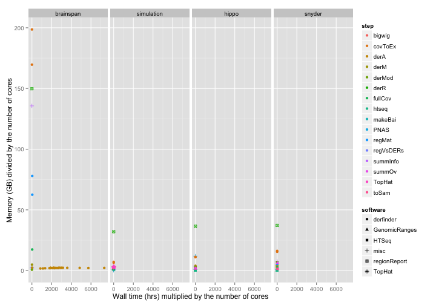

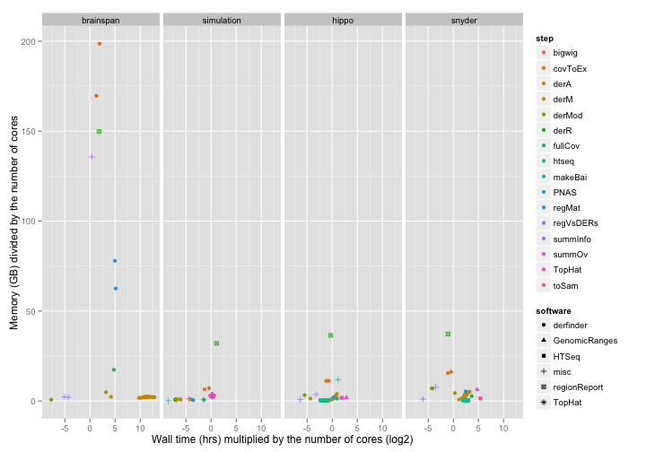

Secondly, points are colored by which analysis type they belong to. Note that the loading data step is required for the single-level and expressed-regions DER approaches as well as exon counting (with derfinder).

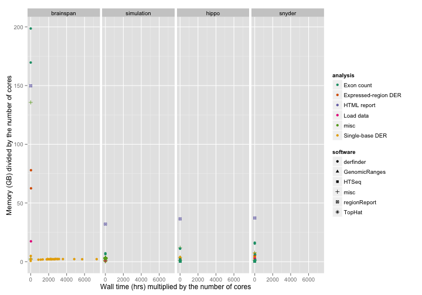

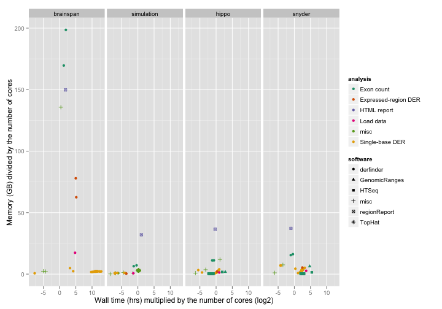

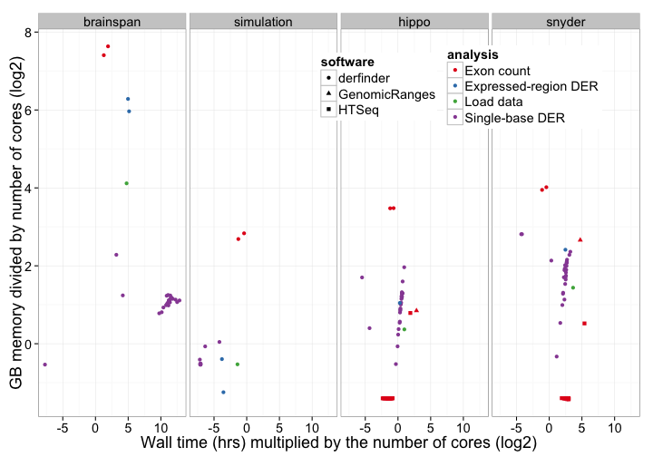

```r
## pdf
##   2
```

## Without cores information

The following plots show the wall time and memory used, but do not take into account how many cores were used.

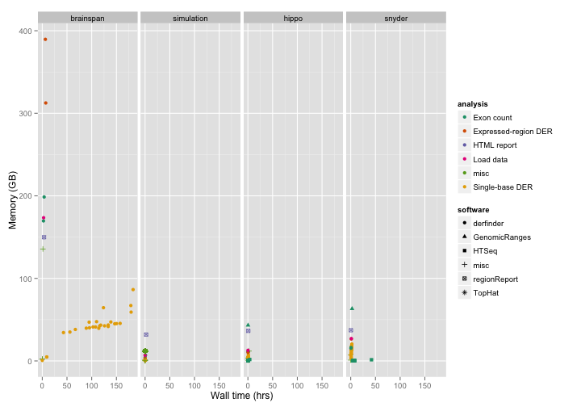

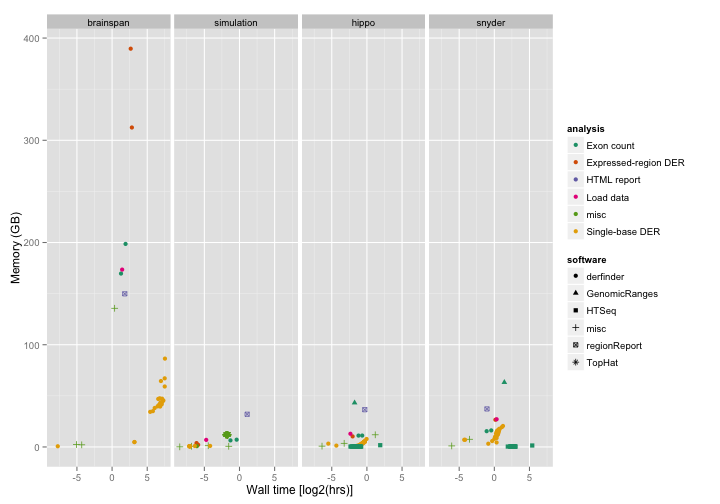

## Size by number of cores

The following plots are similar to those from the previous section. The difference is that the size of the points is determined by the number of cores the job used.

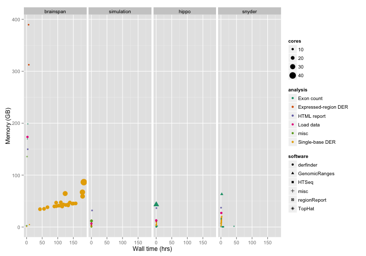

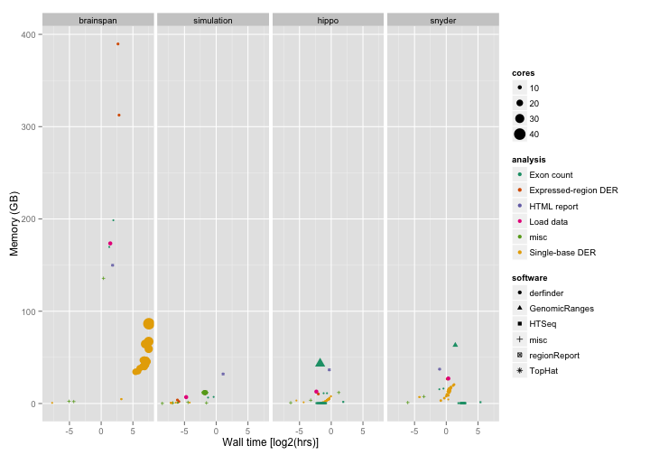

## Panel by cores

The following plot splits the data by row panels which are determined by the number of cores used.

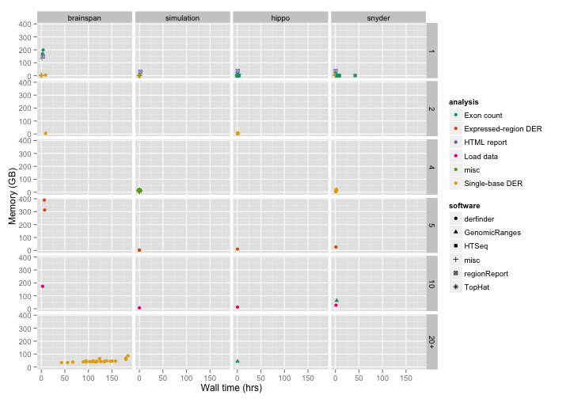

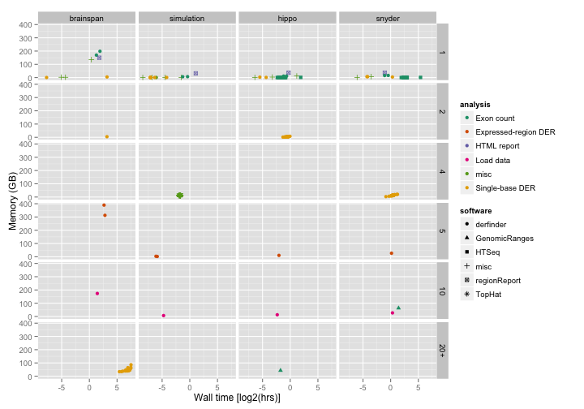

## Resources by step for each analysis

The following plots show per analysis the maximum memory used by a job and maximum wall time for that step. This is assuming that all jobs for a given step ran simultaneously. For example, that all jobs running `derfinder::analyzeChr()` were running at the same time. Note that for some analyses relied on the same steps, like loading the data (*fullCov*).

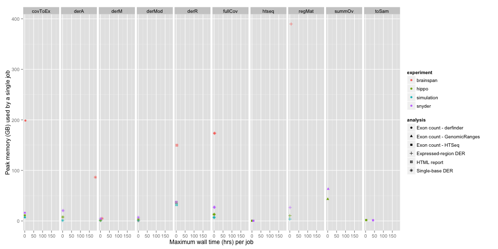

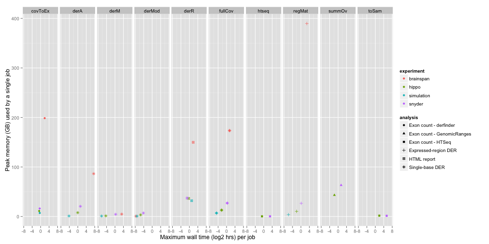

Below are similar plots showing the peak memory by core usage instead of the actual peak memory. This takes into account the number of cores used to run each job.

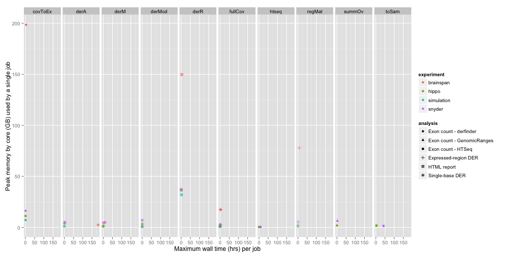

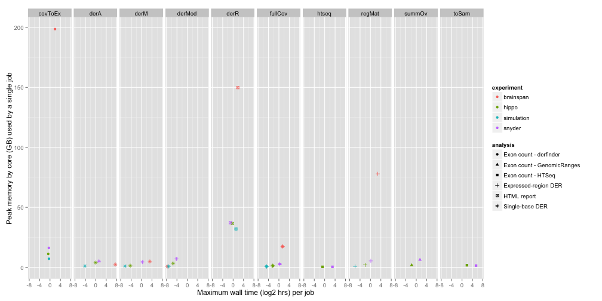

The full table is shown below which can be useful to find the peak number of cores (the sum of cores for all jobs running simultaneously) for a given analysis step.

| memByCore | walltime | memG | peakCores | step | experiment | analysis |
| --- | --- | --- | --- | --- | --- | --- |
| 4.87 | 9.1136 | 4.87 | 1 | derM | brainspan | Single-base DER |
| 2.38 | 183.7903 | 86.43 | 510 | derA | brainspan | Single-base DER |
| 0.69 | 0.0047 | 0.69 | 1 | derMod | brainspan | Single-base DER |
| 17.35 | 2.7008 | 173.50 | 10 | fullCov | brainspan | Single-base DER |
| 0.95 | 0.0122 | 0.95 | 1 | derM | simulation | Single-base DER |
| 1.03 | 0.0553 | 1.03 | 7 | derA | simulation | Single-base DER |
| 0.75 | 0.0069 | 0.75 | 1 | derMod | simulation | Single-base DER |
| 0.69 | 0.0375 | 6.93 | 10 | fullCov | simulation | Single-base DER |
| 1.32 | 0.0492 | 1.32 | 1 | derM | hippo | Single-base DER |
| 3.90 | 0.9697 | 7.80 | 48 | derA | hippo | Single-base DER |
| 3.25 | 0.0222 | 3.25 | 1 | derMod | hippo | Single-base DER |
| 1.29 | 0.1967 | 12.91 | 10 | fullCov | hippo | Single-base DER |
| 4.39 | 1.2494 | 4.39 | 1 | derM | snyder | Single-base DER |
| 5.14 | 2.3453 | 20.55 | 96 | derA | snyder | Single-base DER |
| 7.02 | 0.0558 | 7.02 | 2 | derMod | snyder | Single-base DER |
| 2.71 | 1.2539 | 27.10 | 10 | fullCov | snyder | Single-base DER |
| 77.92 | 7.0422 | 389.60 | 10 | regMat | brainspan | Expressed-region DER |
| 17.35 | 2.7008 | 173.50 | 10 | fullCov | brainspan | Expressed-region DER |
| 0.76 | 0.0169 | 3.80 | 10 | regMat | simulation | Expressed-region DER |
| 0.69 | 0.0375 | 6.93 | 10 | fullCov | simulation | Expressed-region DER |
| 2.07 | 0.2442 | 10.33 | 5 | regMat | hippo | Expressed-region DER |
| 1.29 | 0.1967 | 12.91 | 10 | fullCov | hippo | Expressed-region DER |
| 5.32 | 1.1131 | 26.62 | 5 | regMat | snyder | Expressed-region DER |
| 2.71 | 1.2539 | 27.10 | 10 | fullCov | snyder | Expressed-region DER |
| 149.80 | 3.4858 | 149.80 | 1 | derR | brainspan | HTML report |
| 31.98 | 2.1261 | 31.98 | 1 | derR | simulation | HTML report |
| 36.46 | 0.8094 | 36.46 | 1 | derR | hippo | HTML report |
| 37.20 | 0.4836 | 37.20 | 1 | derR | snyder | HTML report |
| 17.35 | 2.7008 | 173.50 | 10 | fullCov | brainspan | Exon count - derfinder |
| 198.61 | 3.7794 | 198.61 | 2 | covToEx | brainspan | Exon count - derfinder |
| 0.69 | 0.0375 | 6.93 | 10 | fullCov | simulation | Exon count - derfinder |
| 7.13 | 0.7556 | 7.13 | 2 | covToEx | simulation | Exon count - derfinder |
| 1.29 | 0.1967 | 12.91 | 10 | fullCov | hippo | Exon count - derfinder |
| 11.16 | 0.6286 | 11.16 | 2 | covToEx | hippo | Exon count - derfinder |
| 2.71 | 1.2539 | 27.10 | 10 | fullCov | snyder | Exon count - derfinder |
| 16.20 | 0.7375 | 16.20 | 2 | covToEx | snyder | Exon count - derfinder |
| 0.38 | 0.5672 | 0.38 | 31 | htseq | hippo | Exon count - HTSeq |
| 1.73 | 3.7153 | 1.73 | 1 | toSam | hippo | Exon count - HTSeq |
| 0.38 | 7.8933 | 0.38 | 20 | htseq | snyder | Exon count - HTSeq |
| 1.44 | 42.0253 | 1.44 | 1 | toSam | snyder | Exon count - HTSeq |
| 1.80 | 0.2967 | 43.24 | 24 | summOv | hippo | Exon count - GenomicRanges |
| 6.32 | 2.6850 | 63.24 | 10 | summOv | snyder | Exon count - GenomicRanges |

## Resources for each analysis

We can further summarize the resources used by each analysis by identified the maximum memory used in the steps required for a particular analysis and the total wall time for running all the steps when all the jobs of a particular step are running simultaneously. Thus giving us the total actual wall time to run a specific analysis and the maximum memory required.

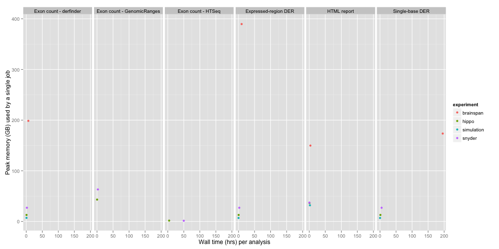

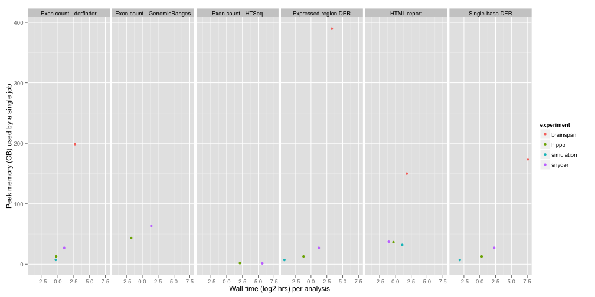

Below are similar plots showing the peak memory by core instead of the actual peak memory for a given job.

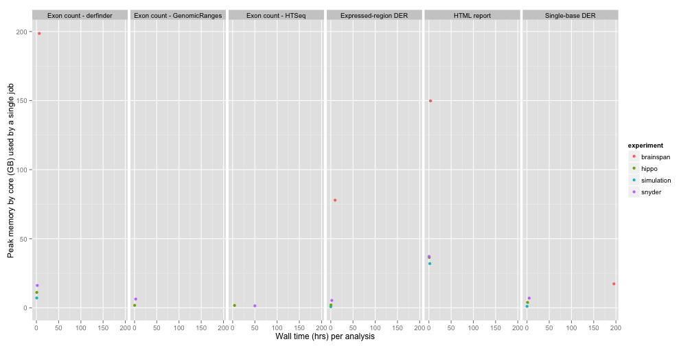

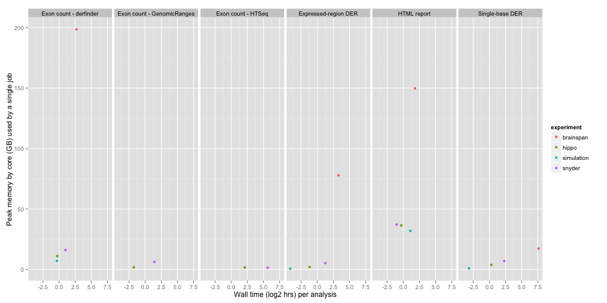

The table below shows the final summary. Note that in some analyses, the peak memory is from the *fullCov* step. We did not focus on reducing the memory load of this step as we sacrificed memory for speed. We know that much lower memory limits can be achieved using 1 core instead of the 10 cores used.

| memByCore | walltime | memG | peakCores | experiment | analysis |
| --- | --- | --- | --- | --- | --- |
| 17.35 | 195.609 | 173.50 | 510 | brainspan | Single-base DER |
| 1.03 | 0.112 | 6.93 | 10 | simulation | Single-base DER |
| 3.90 | 1.238 | 12.91 | 48 | hippo | Single-base DER |
| 7.02 | 4.904 | 27.10 | 96 | snyder | Single-base DER |
| 77.92 | 9.743 | 389.60 | 10 | brainspan | Expressed-region DER |
| 0.76 | 0.054 | 6.93 | 10 | simulation | Expressed-region DER |
| 2.07 | 0.441 | 12.91 | 10 | hippo | Expressed-region DER |
| 5.32 | 2.367 | 27.10 | 10 | snyder | Expressed-region DER |
| 149.80 | 3.486 | 149.80 | 1 | brainspan | HTML report |
| 31.98 | 2.126 | 31.98 | 1 | simulation | HTML report |
| 36.46 | 0.809 | 36.46 | 1 | hippo | HTML report |
| 37.20 | 0.484 | 37.20 | 1 | snyder | HTML report |
| 198.61 | 6.480 | 198.61 | 10 | brainspan | Exon count - derfinder |
| 7.13 | 0.793 | 7.13 | 10 | simulation | Exon count - derfinder |
| 11.16 | 0.825 | 12.91 | 10 | hippo | Exon count - derfinder |
| 16.20 | 1.991 | 27.10 | 10 | snyder | Exon count - derfinder |
| 1.73 | 4.283 | 1.73 | 31 | hippo | Exon count - HTSeq |
| 1.44 | 49.919 | 1.44 | 20 | snyder | Exon count - HTSeq |
| 1.80 | 0.297 | 43.24 | 24 | hippo | Exon count - GenomicRanges |
| 6.32 | 2.685 | 63.24 | 10 | snyder | Exon count - GenomicRanges |

Regarding the high memory load for the HTML report, this could be significantly lowered by only loading the required coverage data used for the plots instead of the full output from the *fullCov* step. Other improvements could be made to the plotting functions, in particular `derfinderPlot::plotCluster()` that would help reduce the peak memory.

## Comparing methods for gene count table generation

The previous table can also be used to compare the sum of the time and peak memory used by the different steps to obtain the exon count table with the following software options.

- `derfinder`: includes resources used for reading coverage data in `R` and then running creating a feature count matrix. We did so for
  - UCSC hg19 knownGene annotation
  - Ensembl GRCh37 p11 annotation.
- `HTSeq`: includes resources used for generating sorted SAM files and then running HTSeq.
- `summOv`: resources used for running `GenomicRanges::summarizeOverlaps()` directly on the BAM files.

# Details

- *timeByCore* is the wall time (in hours) multiplied by the number of cores used. It is a very simple approximation for the wall time used had the job been ran on a single node. This approximation is known to be false, but it gives a basic idea.
- *memByCore* is the memory (in GB) divided by the number of cores used. It is an approximation for the memory used had the job been ran on a single node.

These are the following analysis steps:

1. **fullCov** Extract coverage information from raw files (BAM or BigWig) by chromosome, then filter it, and save it in Rdata files.
2. **derMod** Calculate the sample depth adjustments and build models appropriate for the experiment.
3. **derA** Run single-base level analysis by chromosome.
4. **derM** Merge derfinder analysis results from the different chromosomes, calculate p-values and q-values.
5. **derR** Generate HTML report with `regionReport`.
6. **regMat** Run expressed-regions level analysis with `regionMatrix()`.
7. **regsVsDers** Compare expressed-regions vs single-base level approaches for the derfinder software paper.
8. **toSam** Transform BAM files to sorted (by name) SAM files for running HTSeq.
9. **htseq** Run HTSeq to generate exon count table.
10. **summOv** Run `GenomicRanges::summarizeOverlaps()` to generate exon count table.
11. **covToExon** Generate exon table using `derfinder::coverageToExon()` for UCSC hg19 knownGene or GRCh37 p11 Ensembl annotation table.
12. **PNAS** (Only for *Hippo*) Generate an HTML report comparing the derfinder results vs previously published results (PNAS paper).
13. **TopHat** Run TopHat v2.0.13 for simulated data.
14. **makeBai** Generate .bai files for simulated data.
15. **bigwig** Generate BigWig files from simulated data for a derfinder tutorial: [derTutor](http://lcolladotor.github.io/derTutor/)
16. **summInfo** Summarize results to then use then in the derfinder software paper.

# Reproducibility

Date the report was generated.

```r
## [1] "2015-03-30 22:39:33 EDT"
```

Wallclock time spent generating the report.

```r
## Time difference of 17.223 secs
```

`R` session information.

```r
##  setting  value
##  version  R Under development (unstable) (2014-11-01 r66923)
##  system   x86_64, darwin10.8.0
##  ui       X11
##  language (EN)
##  collate  en_US.UTF-8
##  tz       America/New_York
```

```r
##  package        * version  date       source
##  bibtex           0.4.0    2014-12-31 CRAN (R 3.2.0)
##  bitops           1.0.6    2013-08-17 CRAN (R 3.2.0)
##  chron            2.3.45   2014-02-11 CRAN (R 3.2.0)
##  colorspace       1.2.6    2015-03-11 CRAN (R 3.2.0)
##  data.table     * 1.9.4    2014-10-02 CRAN (R 3.2.0)
##  devtools         1.6.1    2014-10-07 CRAN (R 3.2.0)
##  digest           0.6.8    2014-12-31 CRAN (R 3.2.0)
##  evaluate         0.5.5    2014-04-29 CRAN (R 3.2.0)
##  formatR          1.0      2014-08-25 CRAN (R 3.2.0)
##  ggplot2        * 1.0.0    2014-05-21 CRAN (R 3.2.0)
##  gtable           0.1.2    2012-12-05 CRAN (R 3.2.0)
##  htmltools        0.2.6    2014-09-08 CRAN (R 3.2.0)
##  httr             0.5      2014-09-02 CRAN (R 3.2.0)
##  knitcitations  * 1.0.4    2014-11-03 Github (cboettig/knitcitations@508de74)
##  knitr          * 1.7      2014-10-13 CRAN (R 3.2.0)
##  knitrBootstrap   1.0.0    2014-11-03 Github (jimhester/knitrBootstrap@76c41f0)
##  labeling         0.3      2014-08-23 CRAN (R 3.2.0)
##  lattice          0.20.30  2015-02-22 CRAN (R 3.2.0)
##  lubridate        1.3.3    2013-12-31 CRAN (R 3.2.0)
##  markdown         0.7.4    2014-08-24 CRAN (R 3.2.0)
##  MASS             7.3.40   2015-03-21 CRAN (R 3.2.0)
##  memoise          0.2.1    2014-04-22 CRAN (R 3.2.0)
##  mime             0.3      2015-03-29 CRAN (R 3.2.0)
##  munsell          0.4.2    2013-07-11 CRAN (R 3.2.0)
##  plyr             1.8.1    2014-02-26 CRAN (R 3.2.0)
##  proto            0.3.10   2012-12-22 CRAN (R 3.2.0)
##  rCharts        * 0.4.5    2014-12-17 Github (ramnathv/rCharts@929875d)
##  RColorBrewer     1.1.2    2014-12-07 CRAN (R 3.2.0)
##  Rcpp             0.11.5   2015-03-06 CRAN (R 3.2.0)
##  RCurl            1.95.4.5 2014-12-28 CRAN (R 3.2.0)
##  RefManageR       0.8.40   2014-10-29 CRAN (R 3.2.0)
##  reshape2         1.4.1    2014-12-06 CRAN (R 3.2.0)
##  RJSONIO          1.3.0    2014-07-28 CRAN (R 3.2.0)
##  rmarkdown      * 0.3.3    2014-09-17 CRAN (R 3.2.0)
##  rstudioapi       0.2      2014-12-31 CRAN (R 3.2.0)
##  scales           0.2.4    2014-04-22 CRAN (R 3.2.0)
##  stringr          0.6.2    2012-12-06 CRAN (R 3.2.0)
##  whisker          0.3.2    2013-04-28 CRAN (R 3.2.0)
##  XML              3.98.1.1 2013-06-20 CRAN (R 3.2.0)
##  yaml             2.1.13   2014-06-12 CRAN (R 3.2.0)
```

# Bibliography

This report was generated using `knitrBootstrap` ([Hester, 2014](https://github.com/jimhester/)) with `knitr` ([Xie, 2014](http://www.crcpress.com/product/isbn/9781466561595)) and `rmarkdown` ([Allaire, McPherson, Xie, Wickham, et al., 2014](http://CRAN.R-project.org/package=rmarkdown)) running behind the scenes. Timing information extracted from the SGE reports using `efficiency analytics` ([Frazee, 2014](http://dx.doi.org/10.6084/m9.figshare.878000)). Figures and citations were made using `ggplot2` ([Wickham, 2009](http://had.co.nz/ggplot2/book)) and `knitcitations` ([Boettiger, 2015](https://github.com/cboettig/knitcitations)) respectively.

[1] J. Allaire, J. McPherson, Y. Xie, H. Wickham, et al. *rmarkdown: Dynamic Documents for R*. R package version 0.3.3. 2014. URL: http://CRAN.R-project.org/package=rmarkdown.

[2] S. Anders and W. Huber. “Differential expression analysis for sequence count data”. In: *Genome Biology* 11 (2010), p. R106. DOI: 10.1186/gb-2010-11-10-r106. URL: http://genomebiology.com/2010/11/10/R106/.

[3] C. Boettiger. *knitcitations: Citations for knitr markdown files*. R package version 1.0.4. 2015. URL: https://github.com/cboettig/knitcitations.

[4] A. Frazee. *Efficiency analysis of Sun Grid Engine batch jobs*. 2014. URL: http://dx.doi.org/10.6084/m9.figshare.878000.

[5] J. Hester. *knitrBootstrap: Knitr Bootstrap framework.* R package version 1.0.0. 2014. URL: https://github.com/jimhester/.

[6] M. Lawrence, W. Huber, H. Pagès, P. Aboyoun, et al. “Software for Computing and Annotating Genomic Ranges”. In: *PLoS Computational Biology* 9 (8 2013). DOI: 10.1371/journal.pcbi.1003118. URL: [http://www.ploscompbiol.org/article/info%3Adoi%2F10.1371%2Fjournal.pcbi.1003118}.](http://www.ploscompbiol.org/article/info%253Adoi%252F10.1371%252Fjournal.pcbi.1003118%7d.)

[7] Unknown. *Unknown*. http://samtools.sourceforge.net/. Accessed 2015-03-30. 2015. URL: http://samtools.sourceforge.net/.

[8] Unknown. *Unknown*. http://www-huber.embl.de/users/anders/HTSeq/doc/overview.html. Accessed 2015-03-30. 2015. URL: http://www-huber.embl.de/users/anders/HTSeq/doc/overview.html.

[9] R. Vaidyanathan. *rCharts: Interactive Charts using Javascript Visualization Libraries*. R package version 0.4.5. 2013.

[10] H. Wickham. *ggplot2: elegant graphics for data analysis*. Springer New York, 2009. ISBN: 978-0-387-98140-6. URL: http://had.co.nz/ggplot2/book.

[11] Y. Xie. “knitr: A Comprehensive Tool for Reproducible Research in R”. In: *Implementing Reproducible Computational Research*. Ed. by V. Stodden, F. Leisch and R. D. Peng. ISBN 978-1466561595. Chapman and Hall/CRC, 2014. URL: http://www.crcpress.com/product/isbn/9781466561595.

Styled with knitrBootstrap